# Course Project - Practical Machine Learning

Divya Shree H P

February 3, 2020

# Prediction Assignment Writeup

# I. Overview

This is the report of the Peer Assessment project from Coursera’s course - Practical Machine Learning, as part of the Specialization in Data Science. The main goal of the project is to predict the manner in which 6 participants performed some exercise as described below. This is the “classe” variable in the training set. The machine learning algorithm described here is applied to the 20 test cases available in the test data and the predictions are submitted in appropriate format to the Course Project Prediction Quiz for automated grading.

# II. Data Loading and Exploratory Analysis

## a) Dataset information

The data for this project come from http://groupware.les.inf.puc-rio.br/har.

A short description of the datasets content from the authors’ website:

“Six young health participants were asked to perform one set of 10 repetitions of the Unilateral Dumbbell Biceps Curl in five different fashions: exactly according to the specification (Class A), throwing the elbows to the front (Class B), lifting the dumbbell only halfway (Class C), lowering the dumbbell only halfway (Class D) and throwing the hips to the front (Class E).

Class A corresponds to the specified execution of the exercise, while the other 4 classes correspond to common mistakes. Participants were supervised by an experienced weight lifter to make sure the execution complied to the manner they were supposed to simulate. The exercises were performed by six male participants aged between 20-28 years, with little weight lifting experience. We made sure that all participants could easily simulate the mistakes in a safe and controlled manner by using a relatively light dumbbell (1.25kg)."

## b) Environment preparation

```r
library(knitr)
library(caret)
library(rpart)
library(rpart.plot)
library(rattle)
library(randomForest)
library(corrplot)
library(e1071)
library(gbm)
set.seed(123)
```

## c) Data Loading and Cleaning

The training dataset is then partinioned in 2 to create a Training set (70% of the data) for the modeling process and a Test set (with the remaining 30%) for the validations. The testing dataset is not changed and will only be used for the quiz results generation.

```r
# Download the dataset from URL provided
Train <- "http://d396qusza40orc.cloudfront.net/predmachlearn/pml-training.csv"
Test  <- "http://d396qusza40orc.cloudfront.net/predmachlearn/pml-testing.csv"

# Read the downloaded data files
training <- read.csv(url(Train))
testing  <- read.csv(url(Test))

# create a partition with the training dataset
train_part  <- createDataPartition(training$classe, p=0.7, list=FALSE)
TrainSet <- training[train_part, ]
TestSet  <- training[-train_part, ]
dim(TrainSet)
```

```
## [1] 13737   160
```

The training data set is made of 19622 observations on 160 columns. We can notice that many columns have NA values or blank values on almost every observation. So we will remove them, because they will not produce any information. The first seven columns give information about the people who did the test, and also timestamps. We will not take them in our model.

```r
# Here we get the indexes of the columns having at least 90% of NA or blank values on the training dataset
indColToRemove <- which(colSums(is.na(TrainSet) |TrainSet=="")>0.9*dim(TrainSet)[1])
TrainSetClean <- TrainSet[,-indColToRemove]
TrainSetClean <- TrainSetClean[,-c(1:7)]
dim(TrainSetClean)
```

```
## [1] 13737    53
```

```r
# We do the same for the test set
indColToRemove <- which(colSums(is.na(TestSet) |TestSet=="")>0.9*dim(TestSet)[1])
TestSetClean <- TestSet[,-indColToRemove]
TestSetClean <- TestSetClean[,-1]
dim(TestSetClean)
```

```
## [1] 5885   59
```

## d) Correlation Analysis

A correlation among variables is analysed before proceeding to the modeling procedures.

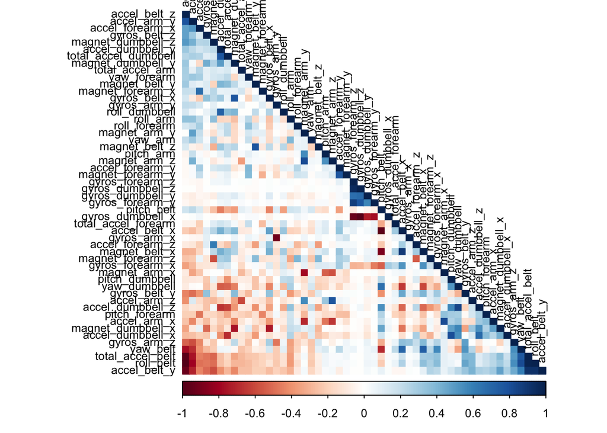

```r
corMatrix <- cor(TrainSetClean[, -53])
corrplot(corMatrix, order = "FPC", method = "color", type = "lower",
         tl.cex = 0.8, tl.col = rgb(0, 0, 0))
```

# III. Prediction Model Building

Three methods will be applied to model the regressions using the Train dataset and the best one with higher accuracy when applied to the Test dataset will be used for the quiz predictions. The methods are: Random Forests, Decision Tree and Generalized Boosted Model. A Confusion Matrix is plotted at the end of each analysis to better visualize the accuracy of the models.

## Method 1 : Random Forest

```r
set.seed(123)
controlRF <- trainControl(method="cv", number=3, verboseIter=FALSE)
modFitRandForest <- train(classe ~ ., data=TrainSetClean, method="rf",
                          trControl=controlRF)
modFitRandForest$finalModel
```

```
##
## Call:
##  randomForest(x = x, y = y, mtry = param$mtry)
##                Type of random forest: classification
##                      Number of trees: 500
## No. of variables tried at each split: 27
##
##         OOB estimate of  error rate: 0.68%
## Confusion matrix:
##      A    B    C    D    E class.error
## A 3901    3    0    0    2 0.001280082
## B   21 2629    7    1    0 0.010910459
## C    0   12 2380    4    0 0.006677796
## D    0    0   27 2222    3 0.013321492
## E    0    1    5    7 2512 0.005148515
```

```r
# prediction on Test dataset
predictRandForest <- predict(modFitRandForest, newdata=TestSetClean)
confMatRandForest <- confusionMatrix(predictRandForest, TestSetClean$classe)
confMatRandForest
```

```
## Confusion Matrix and Statistics
##
##           Reference
## Prediction    A    B    C    D    E
##          A 1671    6    0    0    0
##          B    3 1130    8    0    0
##          C    0    3 1015   16    2
##          D    0    0    3  947    1
##          E    0    0    0    1 1079
##
## Overall Statistics
##
##                Accuracy : 0.9927
##                  95% CI : (0.9902, 0.9947)
##     No Information Rate : 0.2845
##     P-Value [Acc > NIR] : < 2.2e-16
##
##                   Kappa : 0.9908
##
##  Mcnemar's Test P-Value : NA
##
## Statistics by Class:
##
##                      Class: A Class: B Class: C Class: D Class: E
## Sensitivity            0.9982   0.9921   0.9893   0.9824   0.9972
## Specificity            0.9986   0.9977   0.9957   0.9992   0.9998
## Pos Pred Value         0.9964   0.9904   0.9797   0.9958   0.9991
## Neg Pred Value         0.9993   0.9981   0.9977   0.9966   0.9994
## Prevalence             0.2845   0.1935   0.1743   0.1638   0.1839
## Detection Rate         0.2839   0.1920   0.1725   0.1609   0.1833
## Detection Prevalence   0.2850   0.1939   0.1760   0.1616   0.1835
## Balanced Accuracy      0.9984   0.9949   0.9925   0.9908   0.9985
```

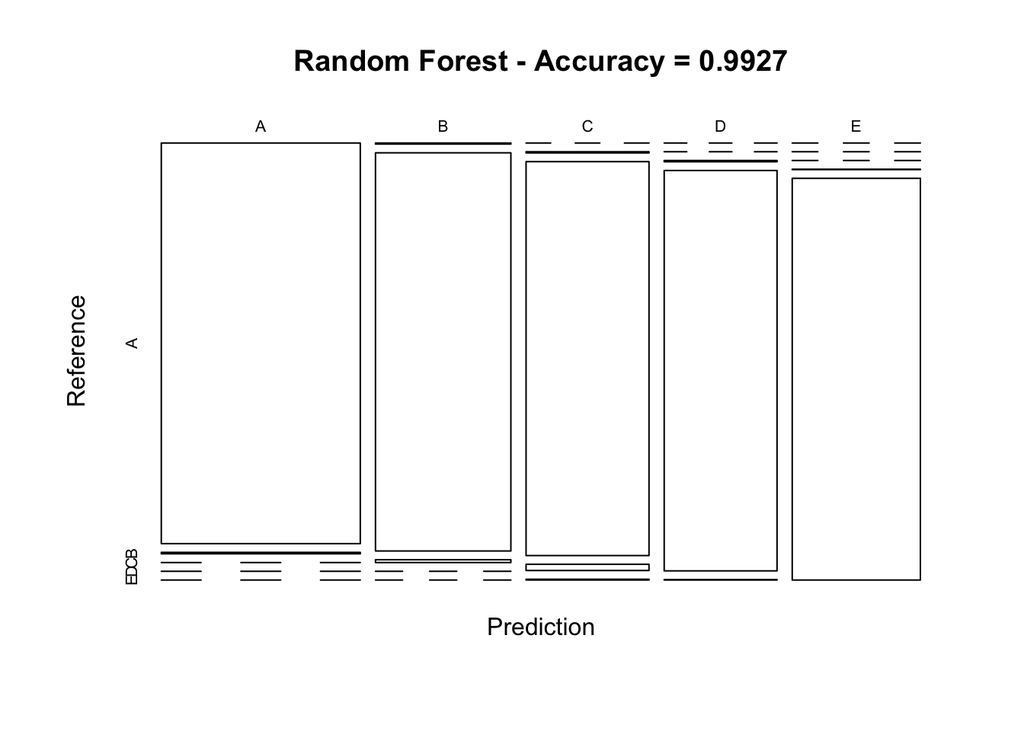

```r
# plot matrix results
plot(confMatRandForest$table, col = confMatRandForest$byClass,
     main = paste("Random Forest - Accuracy =",
                  round(confMatRandForest$overall['Accuracy'], 4)))
```

## Method 2 : Decision Trees

```r
set.seed(123)
modFitDecTree <- rpart(classe ~ ., data=TrainSetClean, method="class")
```

```r
# prediction on Test dataset
predictDecTree <- predict(modFitDecTree, newdata=TestSetClean, type="class")
confMatDecTree <- confusionMatrix(predictDecTree, TestSetClean$classe)
confMatDecTree
```

```
## Confusion Matrix and Statistics
##
##           Reference
## Prediction    A    B    C    D    E
##          A 1424  184   52   56   25
##          B   26  667   54   48   70
##          C   33  107  701   53   52
##          D  167  106  193  735  157
##          E   24   75   26   72  778
##
## Overall Statistics
##
##                Accuracy : 0.7315
##                  95% CI : (0.72, 0.7428)
##     No Information Rate : 0.2845
##     P-Value [Acc > NIR] : < 2.2e-16
##
##                   Kappa : 0.6606
##
##  Mcnemar's Test P-Value : < 2.2e-16
##
## Statistics by Class:
##
##                      Class: A Class: B Class: C Class: D Class: E
## Sensitivity            0.8507   0.5856   0.6832   0.7624   0.7190
## Specificity            0.9247   0.9583   0.9496   0.8734   0.9590
## Pos Pred Value         0.8179   0.7711   0.7410   0.5412   0.7979
## Neg Pred Value         0.9397   0.9060   0.9342   0.9494   0.9381
## Prevalence             0.2845   0.1935   0.1743   0.1638   0.1839
## Detection Rate         0.2420   0.1133   0.1191   0.1249   0.1322
## Detection Prevalence   0.2958   0.1470   0.1607   0.2308   0.1657
## Balanced Accuracy      0.8877   0.7719   0.8164   0.8179   0.8390
```

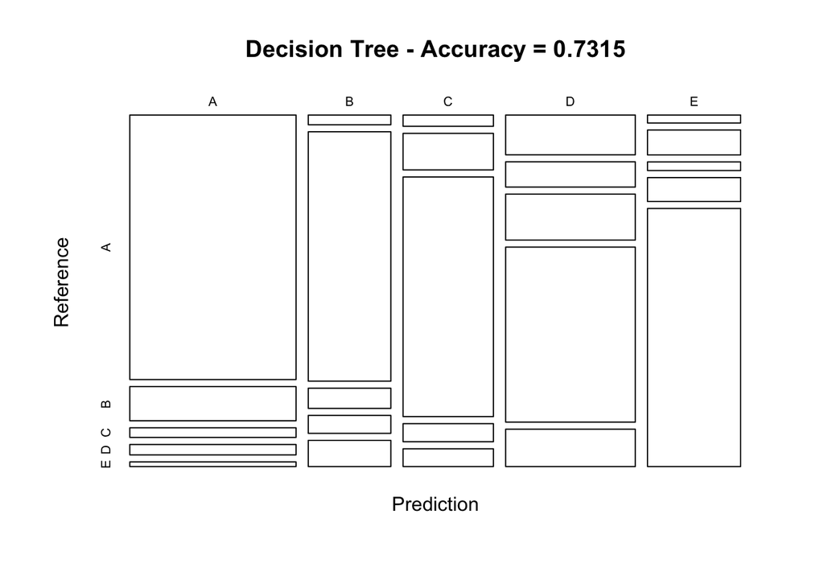

```r
# plot matrix results
plot(confMatDecTree$table, col = confMatDecTree$byClass,
     main = paste("Decision Tree - Accuracy =",
                  round(confMatDecTree$overall['Accuracy'], 4)))
```

## Method 3 : Generalized Boosted Model

```r
set.seed(123)
controlGBM <- trainControl(method = "repeatedcv", number = 5, repeats = 1)
modFitGBM  <- train(classe ~ ., data=TrainSetClean, method = "gbm",
                    trControl = controlGBM, verbose = FALSE)
```

```r
# prediction on Test dataset
predictGBM <- predict(modFitGBM, newdata=TestSetClean)
confMatGBM <- confusionMatrix(predictGBM, TestSetClean$classe)
confMatGBM
```

```
## Confusion Matrix and Statistics
##
##           Reference
## Prediction    A    B    C    D    E
##          A 1646   50    0    0    5
##          B   18 1057   33    0   10
##          C    8   30  979   43    7
##          D    2    2   12  916   14
##          E    0    0    2    5 1046
##
## Overall Statistics
##
##                Accuracy : 0.959
##                  95% CI : (0.9537, 0.964)
##     No Information Rate : 0.2845
##     P-Value [Acc > NIR] : < 2.2e-16
##
##                   Kappa : 0.9482
##
##  Mcnemar's Test P-Value : 1.902e-10
##
## Statistics by Class:
##
##                      Class: A Class: B Class: C Class: D Class: E
## Sensitivity            0.9833   0.9280   0.9542   0.9502   0.9667
## Specificity            0.9869   0.9871   0.9819   0.9939   0.9985
## Pos Pred Value         0.9677   0.9454   0.9175   0.9683   0.9934
## Neg Pred Value         0.9933   0.9828   0.9902   0.9903   0.9925
## Prevalence             0.2845   0.1935   0.1743   0.1638   0.1839
## Detection Rate         0.2797   0.1796   0.1664   0.1556   0.1777
## Detection Prevalence   0.2890   0.1900   0.1813   0.1607   0.1789
## Balanced Accuracy      0.9851   0.9576   0.9680   0.9721   0.9826
```

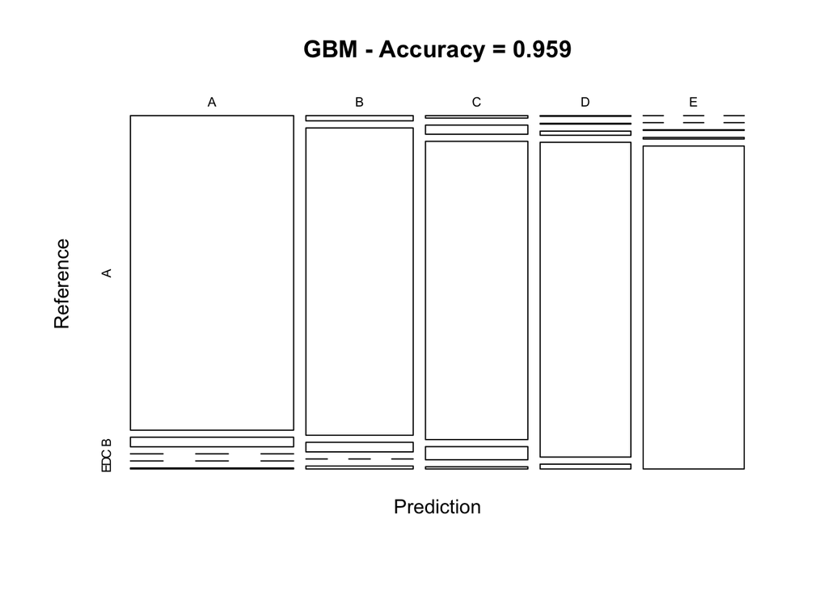

```r
# plot matrix results
plot(confMatGBM$table, col = confMatGBM$byClass,
     main = paste("GBM - Accuracy =", round(confMatGBM$overall['Accuracy'], 4)))
```

# IV. Using the Selected Model to the Test Data

The accuracy of the 3 regression modeling methods used above and accuracies are:

Random Forest : 0.9927 Decision Tree : 0.7315 GBM : 0.959 Based on the results obtained, Random Forest model will be applied to predict the 20 quiz results on testing dataset as shown below.

```r
predictTEST <- predict(modFitRandForest, newdata=testing)
predictTEST
```

```
##  [1] B A B A A E D B A A B C B A E E A B B B
## Levels: A B C D E
```